# Network Analyses

2025-05-21

[output not shown]

## 1. Network overview

Let’s get an idea of the school network. Here I am using the data from the file “edgelist.csv”, where I have directed nominations for 2 categories: “good friends” and “best friends”. I build 2 networks: 1 for “good friends” (Amistad = 1), and one for “best friends” (Amistad = 2). Below, I plot the 2 networks and summarize the main properties in a table and in 3 histograms.

### Good friends

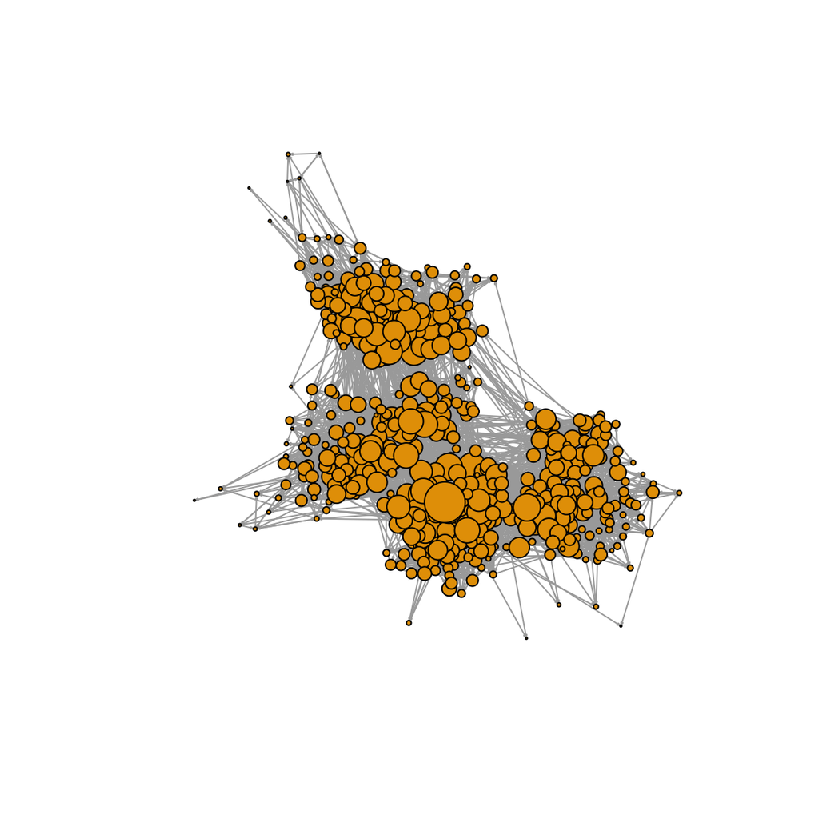

### Best friends

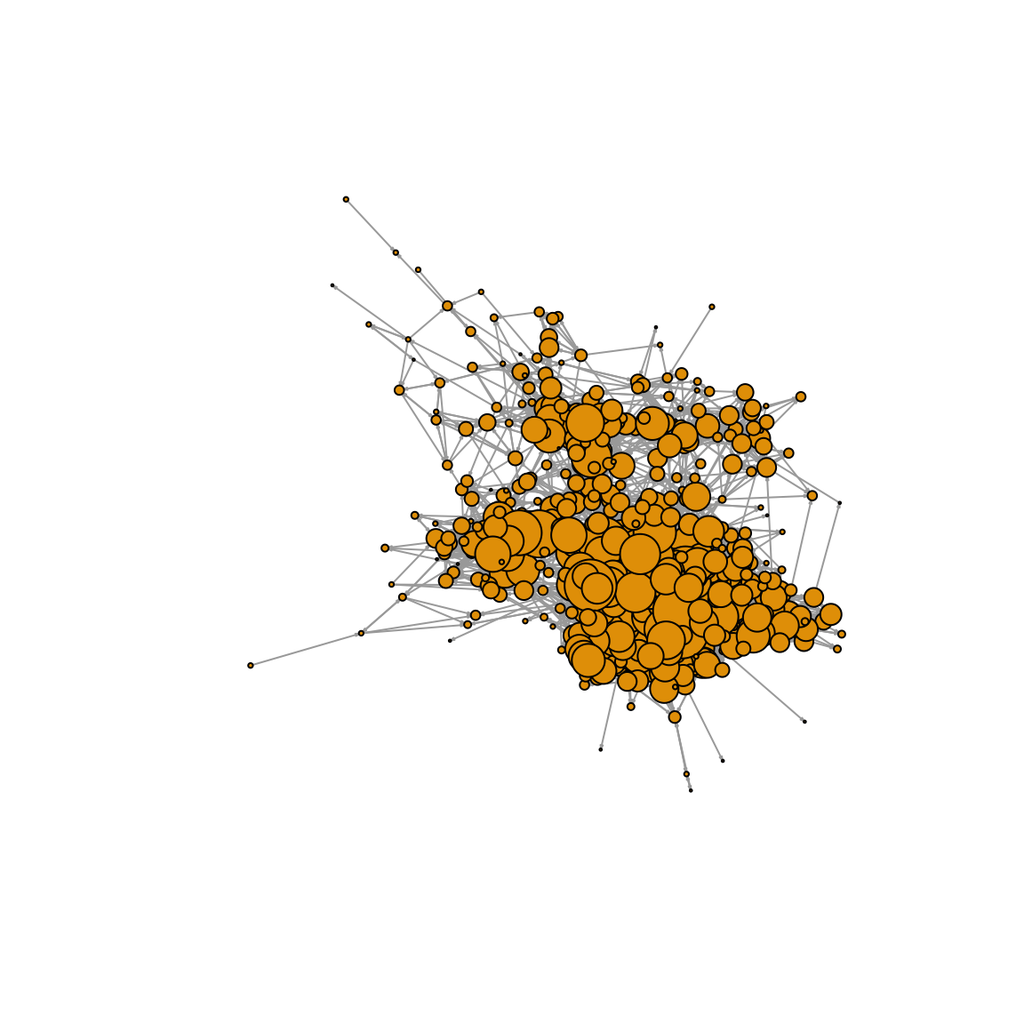

Node size reflects in-degree (the larger the node, the more nominations received)

## Table and visualization of network properties

Table summarizes network properties, plots show the 3 metrics that will later be used in the analyses: 1) In-degree, Eigenvector Centrality, Betweenness Centrality.

### Table

Network Summary

| Metric | GoodFriend | BestFriend |
| --- | --- | --- |
| Average degree | 14.53 | 8.49 |
| Average path length (largest component) | 3.25 | 8.76 |
| Degree (min - max) | 2 - 42 | 0 - 28 |
| Degree SD | 6.27 | 5.15 |
| Density | 0.026 | 0.015 |
| Diameter (largest component) | 7 | 26 |
| Largest component size | 562 | 555 |
| Number of components | 1 | 1 |
| Number of edges | 8165 | 4714 |
| Number of nodes | 562 | 555 |
| Reciprocity | 0.315 | 0.473 |

### Metrics Network Good Friends

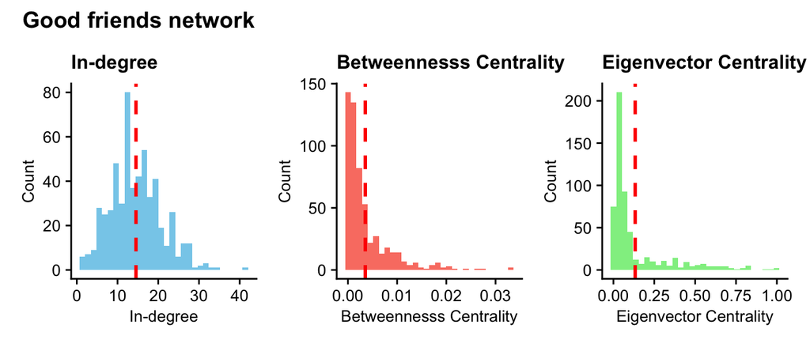

### Metrics Network Best Friends

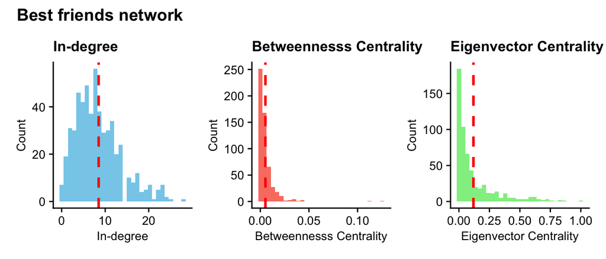

## 2. Analyses on participants who are in the experiment

We now examine the network metrics for participants in the experiment. It may also be useful to compare different methods for computing these metrics.

Another thing to note is that the distribution of eigenvector centrality contains individuals with high values (EC or BC), which may affect the results.

In other words, differences in network metrics may not directly correspond to differences in appropriateness ratings as a function of these metrics.

### Good friends network

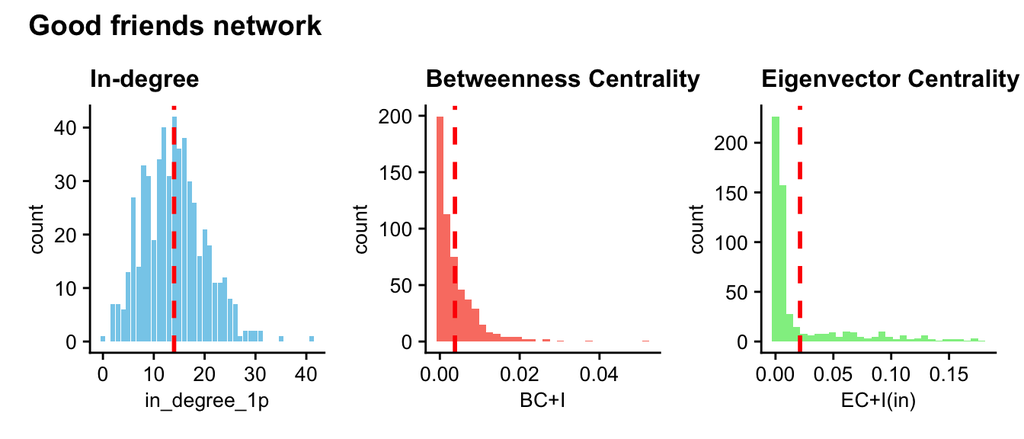

### Best Friends Network

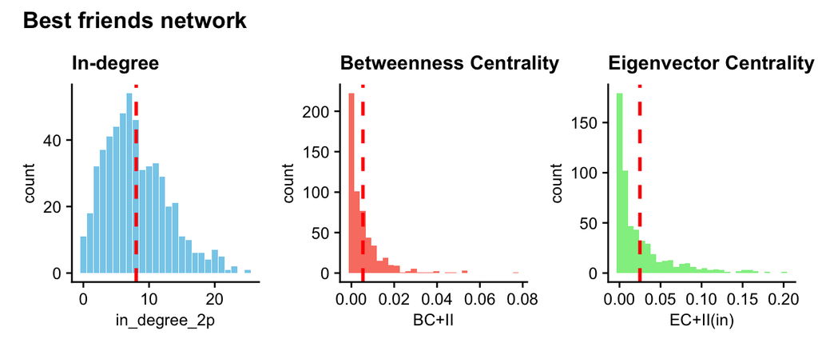

## 3. Regression analyses of appropriateness of violation/punishment of violation

I will start with a simple regression of rating ~ [network metric].

I will use both metrics from the “good-friends” and the “best-friends” social networks. In-degree metrics were standardized for easier interpretation.

## 3.1 Appropriateness ratings by network measures

The only significant predictors of ratings are **in-degree** and **eigenvector** centrality, both with a positive effect. This shows that participants who are more central rate violations as more appropriate.

### In-degree [Good-friends]

|  | rating |  |  |
| --- | --- | --- | --- |
| Predictors | Estimates | CI | p |
| (Intercept) | 1.15 | 1.08 – 1.21 | **<0.001** |
| std in degree 1p | 0.08 | 0.02 – 0.15 | **0.012** |
| Random Effects |  |  |  |
| σ<sup>2</sup> | 1.25 |  |  |
| τ<sub>00</sub> <sub>ID2</sub> | 0.27 |  |  |
| ICC | 0.17 |  |  |
| N <sub>ID2</sub> | 494 |  |  |
| Observations | 2433 |  |  |
| Marginal R<sup>2</sup> / Conditional R<sup>2</sup> | 0.004 / 0.179 |  |  |

### In-degree [Best-friends]

|  | rating |  |  |
| --- | --- | --- | --- |
| Predictors | Estimates | CI | p |
| (Intercept) | 1.15 | 1.08 – 1.21 | **<0.001** |
| std in degree 2p | -0.02 | -0.09 – 0.04 | 0.493 |
| Random Effects |  |  |  |
| σ<sup>2</sup> | 1.25 |  |  |
| τ<sub>00</sub> <sub>ID2</sub> | 0.27 |  |  |
| ICC | 0.18 |  |  |
| N <sub>ID2</sub> | 494 |  |  |
| Observations | 2433 |  |  |
| Marginal R<sup>2</sup> / Conditional R<sup>2</sup> | 0.000 / 0.179 |  |  |

### Betweenness Centrality [Good-friends]

|  | rating |  |  |
| --- | --- | --- | --- |
| Predictors | Estimates | CI | p |
| (Intercept) | 1.13 | 1.05 – 1.21 | **<0.001** |
| BC1 | 4.13 | -7.69 – 15.94 | 0.494 |
| Random Effects |  |  |  |
| σ<sup>2</sup> | 1.25 |  |  |
| τ<sub>00</sub> <sub>ID2</sub> | 0.27 |  |  |
| ICC | 0.18 |  |  |
| N <sub>ID2</sub> | 494 |  |  |
| Observations | 2433 |  |  |
| Marginal R<sup>2</sup> / Conditional R<sup>2</sup> | 0.000 / 0.179 |  |  |

### Betweenness Centrality [Best-friends]

|  | rating |  |  |
| --- | --- | --- | --- |
| Predictors | Estimates | CI | p |
| (Intercept) | 1.12 | 1.05 – 1.20 | **<0.001** |
| BC2 | 4.52 | -2.87 – 11.91 | 0.231 |
| Random Effects |  |  |  |
| σ<sup>2</sup> | 1.25 |  |  |
| τ<sub>00</sub> <sub>ID2</sub> | 0.27 |  |  |
| ICC | 0.18 |  |  |
| N <sub>ID2</sub> | 494 |  |  |
| Observations | 2433 |  |  |
| Marginal R<sup>2</sup> / Conditional R<sup>2</sup> | 0.001 / 0.178 |  |  |

### Eigenvector Centrality [Good-friends]

|  | rating |  |  |
| --- | --- | --- | --- |
| Predictors | Estimates | CI | p |
| (Intercept) | 1.07 | 1.00 – 1.15 | **<0.001** |
| EC1 | 3.34 | 1.69 – 4.99 | **<0.001** |
| Random Effects |  |  |  |
| σ<sup>2</sup> | 1.25 |  |  |
| τ<sub>00</sub> <sub>ID2</sub> | 0.25 |  |  |
| ICC | 0.17 |  |  |
| N <sub>ID2</sub> | 494 |  |  |
| Observations | 2433 |  |  |
| Marginal R<sup>2</sup> / Conditional R<sup>2</sup> | 0.011 / 0.178 |  |  |

### Eigenvector Centrality [Best-friends]

|  | rating |  |  |
| --- | --- | --- | --- |
| Predictors | Estimates | CI | p |
| (Intercept) | 1.18 | 1.10 – 1.26 | **<0.001** |
| EC2 | -1.13 | -2.95 – 0.69 | 0.225 |
| Random Effects |  |  |  |
| σ<sup>2</sup> | 1.25 |  |  |
| τ<sub>00</sub> <sub>ID2</sub> | 0.27 |  |  |
| ICC | 0.18 |  |  |
| N <sub>ID2</sub> | 494 |  |  |
| Observations | 2433 |  |  |
| Marginal R<sup>2</sup> / Conditional R<sup>2</sup> | 0.001 / 0.178 |  |  |

## 3.2 Appropriateness ratings by network measures and treatment

This means that ratings of approppriateness of a violation of a friend vs. a non-friend were not related with the centrality of the rater.

### In-degree [Good-friends]

|  | rating |  |  |
| --- | --- | --- | --- |
| Predictors | Estimates | CI | p |
| (Intercept) | 0.88 | 0.68 – 1.08 | **<0.001** |
| in degree 1p | 0.01 | 0.00 – 0.03 | **0.036** |
| treatmentf | 0.14 | -0.09 – 0.37 | 0.232 |
| in degree 1p × treatmentf | -0.00 | -0.02 – 0.01 | 0.953 |
| Random Effects |  |  |  |
| σ<sup>2</sup> | 1.25 |  |  |
| τ<sub>00</sub> <sub>ID2</sub> | 0.26 |  |  |
| ICC | 0.18 |  |  |
| N <sub>ID2</sub> | 494 |  |  |
| Observations | 2433 |  |  |
| Marginal R<sup>2</sup> / Conditional R<sup>2</sup> | 0.007 / 0.181 |  |  |

### In-degree [Best-friends]

|  | rating |  |  |
| --- | --- | --- | --- |
| Predictors | Estimates | CI | p |
| (Intercept) | 1.08 | 1.00 – 1.16 | **<0.001** |
| std in degree 2p | -0.03 | -0.11 – 0.05 | 0.412 |
| treatmentf | 0.13 | 0.04 – 0.22 | **0.003** |
| std in degree 2p × treatmentf | 0.02 | -0.07 – 0.11 | 0.644 |
| Random Effects |  |  |  |
| σ<sup>2</sup> | 1.25 |  |  |
| τ<sub>00</sub> <sub>ID2</sub> | 0.27 |  |  |
| ICC | 0.18 |  |  |
| N <sub>ID2</sub> | 494 |  |  |
| Observations | 2433 |  |  |
| Marginal R<sup>2</sup> / Conditional R<sup>2</sup> | 0.003 / 0.181 |  |  |

### Betweenness Centrality [Good-friends]

|  | rating |  |  |
| --- | --- | --- | --- |
| Predictors | Estimates | CI | p |
| (Intercept) | 1.07 | 0.97 – 1.17 | **<0.001** |
| BC1 | 3.04 | -11.29 – 17.37 | 0.678 |
| treatmentf | 0.13 | 0.02 – 0.24 | **0.026** |
| BC1 × treatmentf | 2.13 | -14.44 – 18.69 | 0.801 |
| Random Effects |  |  |  |
| σ<sup>2</sup> | 1.25 |  |  |
| τ<sub>00</sub> <sub>ID2</sub> | 0.27 |  |  |
| ICC | 0.18 |  |  |
| N <sub>ID2</sub> | 494 |  |  |
| Observations | 2433 |  |  |
| Marginal R<sup>2</sup> / Conditional R<sup>2</sup> | 0.003 / 0.181 |  |  |

### Betweenness Centrality [Best-friends]

|  | rating |  |  |
| --- | --- | --- | --- |
| Predictors | Estimates | CI | p |
| (Intercept) | 1.07 | 0.97 – 1.16 | **<0.001** |
| BC2 | 2.45 | -6.41 – 11.31 | 0.588 |
| treatmentf | 0.11 | 0.00 – 0.22 | **0.043** |
| BC2 × treatmentf | 4.45 | -5.93 – 14.83 | 0.401 |
| Random Effects |  |  |  |
| σ<sup>2</sup> | 1.25 |  |  |
| τ<sub>00</sub> <sub>ID2</sub> | 0.27 |  |  |
| ICC | 0.18 |  |  |
| N <sub>ID2</sub> | 494 |  |  |
| Observations | 2433 |  |  |
| Marginal R<sup>2</sup> / Conditional R<sup>2</sup> | 0.004 / 0.181 |  |  |

### Eigenvector Centrality [Good-friends]

|  | rating |  |  |
| --- | --- | --- | --- |
| Predictors | Estimates | CI | p |
| (Intercept) | 1.00 | 0.91 – 1.09 | **<0.001** |
| EC1 | 3.40 | 1.39 – 5.41 | **0.001** |
| treatmentf | 0.14 | 0.03 – 0.24 | **0.009** |
| EC1 × treatmentf | -0.11 | -2.45 – 2.24 | 0.930 |
| Random Effects |  |  |  |
| σ<sup>2</sup> | 1.25 |  |  |
| τ<sub>00</sub> <sub>ID2</sub> | 0.25 |  |  |
| ICC | 0.17 |  |  |
| N <sub>ID2</sub> | 494 |  |  |
| Observations | 2433 |  |  |
| Marginal R<sup>2</sup> / Conditional R<sup>2</sup> | 0.014 / 0.181 |  |  |

### Eigenvector Centrality [Best-friends]

|  | rating |  |  |
| --- | --- | --- | --- |
| Predictors | Estimates | CI | p |
| (Intercept) | 1.11 | 1.02 – 1.21 | **<0.001** |
| EC2 | -1.32 | -3.53 – 0.89 | 0.243 |
| treatmentf | 0.12 | 0.01 – 0.24 | **0.027** |
| EC2 × treatmentf | 0.40 | -2.16 – 2.95 | 0.761 |
| Random Effects |  |  |  |
| σ<sup>2</sup> | 1.25 |  |  |
| τ<sub>00</sub> <sub>ID2</sub> | 0.27 |  |  |
| ICC | 0.18 |  |  |
| N <sub>ID2</sub> | 494 |  |  |
| Observations | 2433 |  |  |
| Marginal R<sup>2</sup> / Conditional R<sup>2</sup> | 0.004 / 0.181 |  |  |

## 4 Punishment

We now turn to the appropriateness of punishment. Remember here that the rater is not the one punishing, but rather they are rating how appropriate it is for a friend, to punish a friend/non-friends.

## 4.1 Appropriatness of punishment by network measures

First we only look at appropriateness of punishment as a function of network metrics.

### In-degree [Good-friends]

|  | rating |  |  |
| --- | --- | --- | --- |
| Predictors | Estimates | CI | p |
| (Intercept) | 2.42 | 2.38 – 2.46 | **<0.001** |
| std in degree 1p | 0.03 | -0.01 – 0.07 | 0.161 |
| Random Effects |  |  |  |
| σ<sup>2</sup> | 1.60 |  |  |
| τ<sub>00</sub> <sub>ID2</sub> | 0.14 |  |  |
| ICC | 0.08 |  |  |
| N <sub>ID2</sub> | 494 |  |  |
| Observations | 10178 |  |  |
| Marginal R<sup>2</sup> / Conditional R<sup>2</sup> | 0.000 / 0.080 |  |  |

### In-degree [Best-friends]

|  | rating |  |  |
| --- | --- | --- | --- |
| Predictors | Estimates | CI | p |
| (Intercept) | 2.42 | 2.38 – 2.46 | **<0.001** |
| std in degree 2p | 0.00 | -0.04 – 0.05 | 0.820 |
| Random Effects |  |  |  |
| σ<sup>2</sup> | 1.60 |  |  |
| τ<sub>00</sub> <sub>ID2</sub> | 0.14 |  |  |
| ICC | 0.08 |  |  |
| N <sub>ID2</sub> | 494 |  |  |
| Observations | 10178 |  |  |
| Marginal R<sup>2</sup> / Conditional R<sup>2</sup> | 0.000 / 0.080 |  |  |

### Betweennesss Centrality [Good-Friends]

|  | rating |  |  |
| --- | --- | --- | --- |
| Predictors | Estimates | CI | p |
| (Intercept) | 2.41 | 2.36 – 2.46 | **<0.001** |
| BC1 | 2.27 | -5.32 – 9.86 | 0.558 |
| Random Effects |  |  |  |
| σ<sup>2</sup> | 1.60 |  |  |
| τ<sub>00</sub> <sub>ID2</sub> | 0.14 |  |  |
| ICC | 0.08 |  |  |
| N <sub>ID2</sub> | 494 |  |  |
| Observations | 10178 |  |  |
| Marginal R<sup>2</sup> / Conditional R<sup>2</sup> | 0.000 / 0.080 |  |  |

### Betweennesss Centrality [Best-Friends]

|  | rating |  |  |
| --- | --- | --- | --- |
| Predictors | Estimates | CI | p |
| (Intercept) | 2.40 | 2.35 – 2.45 | **<0.001** |
| BC2 | 4.03 | -0.71 – 8.77 | 0.096 |
| Random Effects |  |  |  |
| σ<sup>2</sup> | 1.60 |  |  |
| τ<sub>00</sub> <sub>ID2</sub> | 0.14 |  |  |
| ICC | 0.08 |  |  |
| N <sub>ID2</sub> | 494 |  |  |
| Observations | 10178 |  |  |
| Marginal R<sup>2</sup> / Conditional R<sup>2</sup> | 0.001 / 0.080 |  |  |

### Eigenvector Centrality [Good-Friends]

|  | rating |  |  |
| --- | --- | --- | --- |
| Predictors | Estimates | CI | p |
| (Intercept) | 2.39 | 2.34 – 2.44 | **<0.001** |
| EC1 | 1.36 | 0.28 – 2.43 | **0.013** |
| Random Effects |  |  |  |
| σ<sup>2</sup> | 1.60 |  |  |
| τ<sub>00</sub> <sub>ID2</sub> | 0.14 |  |  |
| ICC | 0.08 |  |  |
| N <sub>ID2</sub> | 494 |  |  |
| Observations | 10178 |  |  |
| Marginal R<sup>2</sup> / Conditional R<sup>2</sup> | 0.002 / 0.080 |  |  |

### Eigenvector Centrality [Best-Friends]

|  | rating |  |  |
| --- | --- | --- | --- |
| Predictors | Estimates | CI | p |
| (Intercept) | 2.45 | 2.39 – 2.50 | **<0.001** |
| EC2 | -0.94 | -2.11 – 0.23 | 0.115 |
| Random Effects |  |  |  |
| σ<sup>2</sup> | 1.60 |  |  |
| τ<sub>00</sub> <sub>ID2</sub> | 0.14 |  |  |
| ICC | 0.08 |  |  |
| N <sub>ID2</sub> | 494 |  |  |
| Observations | 10178 |  |  |
| Marginal R<sup>2</sup> / Conditional R<sup>2</sup> | 0.001 / 0.080 |  |  |

## 4.2 Appropriatness of punishment by network measures * treatment

### In-degree [Good-Friends]

|  | rating |  |  |
| --- | --- | --- | --- |
| Predictors | Estimates | CI | p |
| (Intercept) | 2.42 | 2.37 – 2.47 | **<0.001** |
| std in degree 1p | 0.04 | -0.01 – 0.08 | 0.152 |
| treatmentf | 0.00 | -0.04 – 0.05 | 0.848 |
| std in degree 1p × treatmentf | -0.01 | -0.06 – 0.04 | 0.653 |
| Random Effects |  |  |  |
| σ<sup>2</sup> | 1.60 |  |  |
| τ<sub>00</sub> <sub>ID2</sub> | 0.14 |  |  |
| ICC | 0.08 |  |  |
| N <sub>ID2</sub> | 494 |  |  |
| Observations | 10178 |  |  |
| Marginal R<sup>2</sup> / Conditional R<sup>2</sup> | 0.001 / 0.080 |  |  |

### In-degree [Best-Friends]

|  | rating |  |  |
| --- | --- | --- | --- |
| Predictors | Estimates | CI | p |
| (Intercept) | 2.42 | 2.37 – 2.47 | **<0.001** |
| std in degree 2p | 0.01 | -0.04 – 0.06 | 0.621 |
| treatmentf | 0.00 | -0.04 – 0.05 | 0.843 |
| std in degree 2p × treatmentf | -0.01 | -0.06 – 0.03 | 0.563 |
| Random Effects |  |  |  |
| σ<sup>2</sup> | 1.60 |  |  |
| τ<sub>00</sub> <sub>ID2</sub> | 0.14 |  |  |
| ICC | 0.08 |  |  |
| N <sub>ID2</sub> | 494 |  |  |
| Observations | 10178 |  |  |
| Marginal R<sup>2</sup> / Conditional R<sup>2</sup> | 0.000 / 0.080 |  |  |

### Betweenness Centrality [Good-Friends]

|  | rating |  |  |
| --- | --- | --- | --- |
| Predictors | Estimates | CI | p |
| (Intercept) | 2.40 | 2.34 – 2.46 | **<0.001** |
| BC1 | 5.62 | -3.21 – 14.45 | 0.212 |
| treatmentf | 0.03 | -0.03 – 0.09 | 0.316 |
| BC1 × treatmentf | -6.78 | -15.91 – 2.35 | 0.145 |
| Random Effects |  |  |  |
| σ<sup>2</sup> | 1.60 |  |  |
| τ<sub>00</sub> <sub>ID2</sub> | 0.14 |  |  |
| ICC | 0.08 |  |  |
| N <sub>ID2</sub> | 494 |  |  |
| Observations | 10178 |  |  |
| Marginal R<sup>2</sup> / Conditional R<sup>2</sup> | 0.000 / 0.080 |  |  |

### Betweenness Centrality [Best-Friends]

|  | rating |  |  |
| --- | --- | --- | --- |
| Predictors | Estimates | CI | p |
| (Intercept) | 2.39 | 2.33 – 2.45 | **<0.001** |
| BC2 | 4.93 | -0.55 – 10.42 | 0.078 |
| treatmentf | 0.02 | -0.04 – 0.07 | 0.617 |
| BC2 × treatmentf | -1.88 | -7.59 – 3.84 | 0.520 |
| Random Effects |  |  |  |
| σ<sup>2</sup> | 1.60 |  |  |
| τ<sub>00</sub> <sub>ID2</sub> | 0.14 |  |  |
| ICC | 0.08 |  |  |
| N <sub>ID2</sub> | 494 |  |  |
| Observations | 10178 |  |  |
| Marginal R<sup>2</sup> / Conditional R<sup>2</sup> | 0.001 / 0.080 |  |  |

### Eigenvector Centrality [Good-Friends]

|  | rating |  |  |
| --- | --- | --- | --- |
| Predictors | Estimates | CI | p |
| (Intercept) | 2.38 | 2.33 – 2.44 | **<0.001** |
| EC1 | 1.57 | 0.32 – 2.81 | **0.014** |
| treatmentf | 0.01 | -0.04 – 0.07 | 0.626 |
| EC1 × treatmentf | -0.43 | -1.72 – 0.87 | 0.517 |
| Random Effects |  |  |  |
| σ<sup>2</sup> | 1.60 |  |  |
| τ<sub>00</sub> <sub>ID2</sub> | 0.14 |  |  |
| ICC | 0.08 |  |  |
| N <sub>ID2</sub> | 494 |  |  |
| Observations | 10178 |  |  |
| Marginal R<sup>2</sup> / Conditional R<sup>2</sup> | 0.002 / 0.080 |  |  |

### Eigenvector Centrality [Best-Friends]

|  | rating |  |  |
| --- | --- | --- | --- |
| Predictors | Estimates | CI | p |
| (Intercept) | 2.44 | 2.38 – 2.50 | **<0.001** |
| EC2 | -0.89 | -2.25 – 0.47 | 0.202 |
| treatmentf | 0.01 | -0.05 – 0.07 | 0.819 |
| EC2 × treatmentf | -0.11 | -1.52 – 1.30 | 0.879 |
| Random Effects |  |  |  |
| σ<sup>2</sup> | 1.60 |  |  |
| τ<sub>00</sub> <sub>ID2</sub> | 0.14 |  |  |
| ICC | 0.08 |  |  |
| N <sub>ID2</sub> | 494 |  |  |
| Observations | 10178 |  |  |
| Marginal R<sup>2</sup> / Conditional R<sup>2</sup> | 0.001 / 0.080 |  |  |

## 3-level interaction

|  | rating |  |  |
| --- | --- | --- | --- |
| Predictors | Estimates | CI | p |
| (Intercept) | 2.43 | 2.32 – 2.54 | **<0.001** |
| EC1 | 1.51 | -0.78 – 3.79 | 0.196 |
| treatmentf | -0.00 | -0.15 – 0.15 | 0.984 |
| domain [interrupt] | -0.13 | -0.28 – 0.02 | 0.086 |
| domain [online] | -0.07 | -0.20 – 0.06 | 0.301 |
| domain [stealing] | 0.07 | -0.08 – 0.21 | 0.351 |
| domain [texting] | -0.14 | -0.27 – -0.01 | **0.040** |
| EC1 × treatmentf | -0.53 | -3.97 – 2.91 | 0.763 |
| EC1 × domain [interrupt] | 0.64 | -2.78 – 4.07 | 0.712 |
| EC1 × domain [online] | 0.00 | -2.79 – 2.79 | 0.999 |
| EC1 × domain [stealing] | 0.47 | -2.80 – 3.75 | 0.777 |
| EC1 × domain [texting] | -0.59 | -3.38 – 2.19 | 0.676 |
| treatmentf × domain [interrupt] | -0.01 | -0.25 – 0.23 | 0.964 |
| treatmentf × domain [online] | 0.21 | 0.02 – 0.39 | **0.028** |
| treatmentf × domain [stealing] | 0.02 | -0.21 – 0.25 | 0.887 |
| treatmentf × domain [texting] | -0.12 | -0.31 – 0.06 | 0.199 |
| (EC1 × treatmentf) × domain [interrupt] | -0.34 | -5.77 – 5.10 | 0.904 |
| (EC1 × treatmentf) × domain [online] | -1.02 | -5.22 – 3.18 | 0.635 |
| (EC1 × treatmentf) × domain [stealing] | -0.23 | -5.50 – 5.04 | 0.932 |
| (EC1 × treatmentf) × domain [texting] | 1.80 | -2.39 – 5.98 | 0.400 |
| Random Effects |  |  |  |
| σ<sup>2</sup> | 1.59 |  |  |
| τ<sub>00</sub> <sub>ID2</sub> | 0.14 |  |  |
| ICC | 0.08 |  |  |
| N <sub>ID2</sub> | 494 |  |  |
| Observations | 10178 |  |  |
| Marginal R<sup>2</sup> / Conditional R<sup>2</sup> | 0.009 / 0.088 |  |  |

## Vizualization of main regression results

Showing the most interesting results across all regressions

### Violation rating ~ In-degree

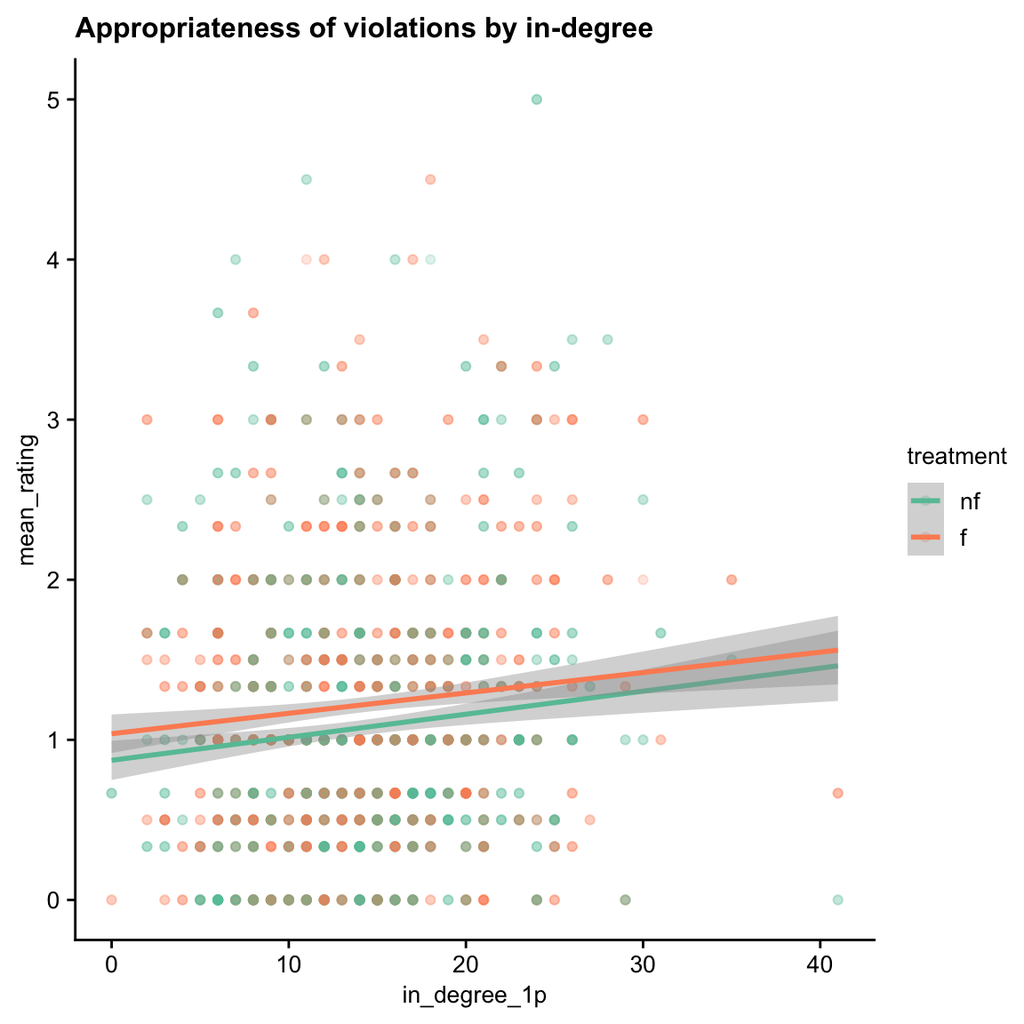

The higher participants’ in degree, the higher the appropriateness rating. Ratings are averaged across the 5 domain for each participants: Each dot is 1 participant in 1 treatment (nf = non-friend, f = friend)

### Violation rating ~ Eigenvector Centrality

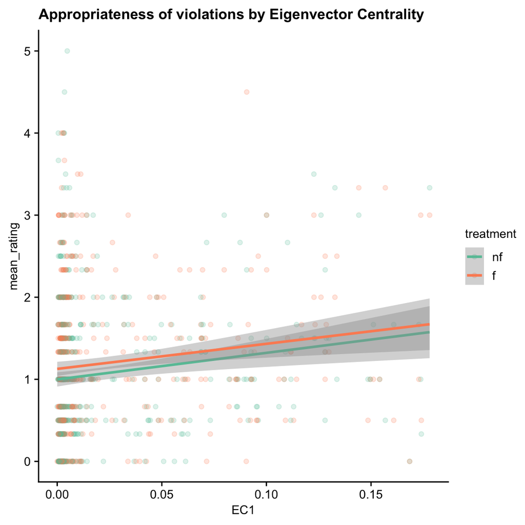

### Punishment Rating ~ Eigenvector Centrality

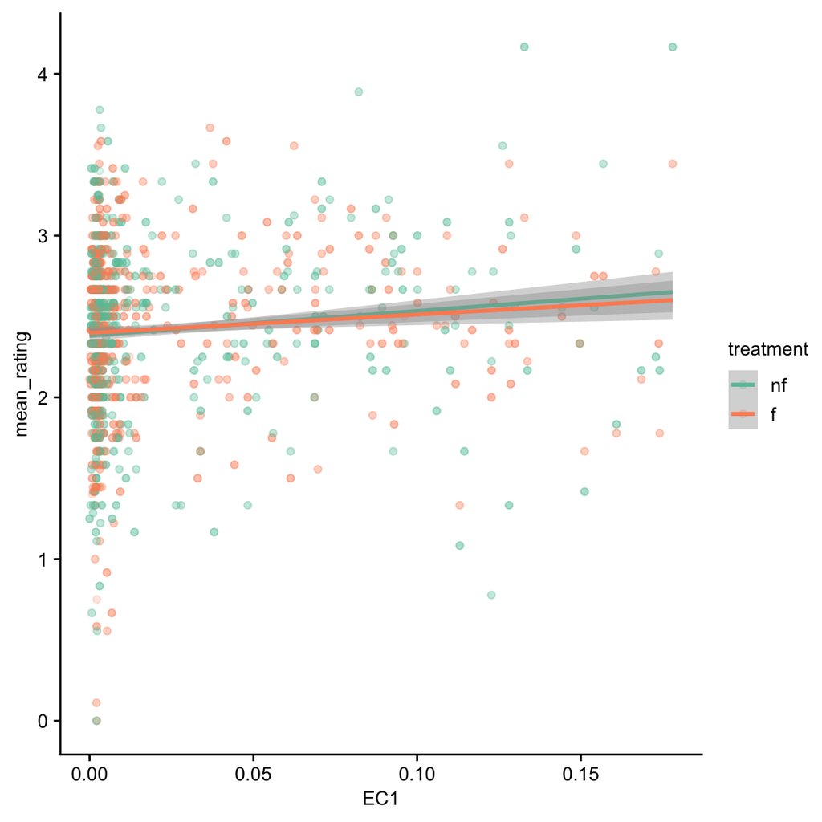

### Punishment Rating ~ Eigenvector Centrality * Treatment * Domain

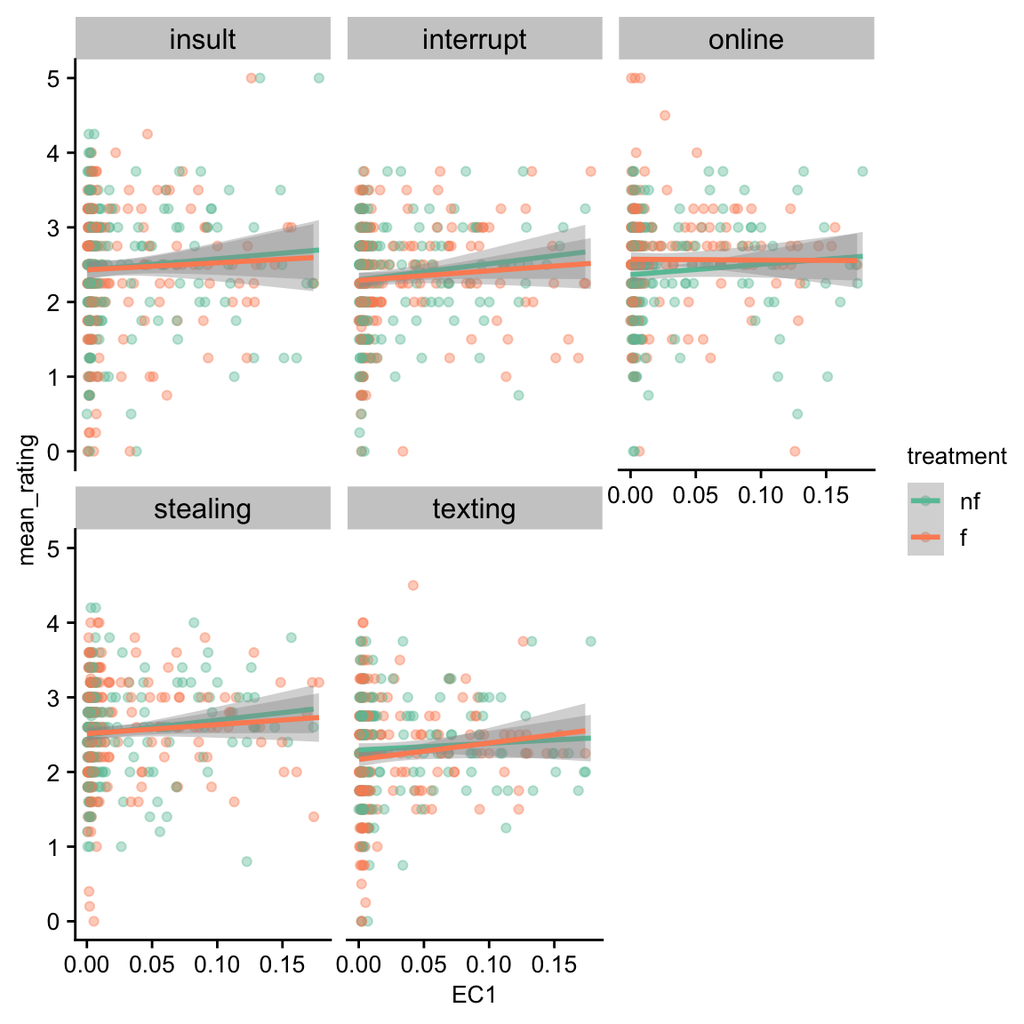